# AI_Pipeline_Tutorial

**Detecting Plant Diseases with PyTorch**

A Pipeline for Real-Time Crop Health Monitoring

**Abstract:**  
This tutorial showcases a machine learning pipeline using PyTorch with the objective of detecting plant diseases from crop leaf images presenting symptoms like discolouration, spots, and wilting. The PlantVillage dataset is chosen for this purpose, and the pipeline includes data preprocessing with augmentation, splitting the dataset, and the development of a custom convolutional neural network (CNN). Hyperparameter experiments are also conducted to evaluate the impact of different learning rates, dropout levels, and batch sizes, with results visualised through graphs and tables to evaluate the different variations.

1. Introduction
   - 1.1 Motivation: AI for Sustainable Agriculture
   - 1.2 Learning Objectives
2. Data Management
   - 2.1 Overview of the PlantVillage Dataset
   - 2.2 Loading and Preprocessing Data
   - 2.3 Visualising Sample Images from the Dataset
   - 2.4 Splitting Data into Train/Validation/Test Sets
3. Custom CNN Architecture for Plant Disease Detection
   - 3.1 Custom CNN: Layer-by-Layer Implementation
   - 3.2 Visualising the Model Architecture
4. Training Pipeline and Evaluation
   - 4.1 Setup: Device and Optimiser Configuration
   - 4.2 Training and Validation Loops
   - 4.3 Evaluating the Model on Test Data
   - 4.4 Visual Insight into Model Predictions
5. Hyperparameter Analysis and Results Visualisation
   - 5.1 Experiment 1: Learning Rate Analysis
   - 5.2 Experiment 2: Dropout Rate Analysis
   - 5.3 Experiment 3: Batch Size Analysis
   - 5.4 Summary of Optimal Hyperparameter Findings
6. Comparison of Similar Tutorials
7. Conclusion
8. References

# 1. Introduction

Welcome to this tutorial where we explore the application of Artificial Intelligence (AI) in the context of agricultural practices. As the global population increases, agriculture needs innovative solutions to help manage crop diseases. This tutorial uses PyTorch to develop a machine learning pipeline that detects plant diseases early, with the goal of reducing crop losses and minimising pesticide use, hopefully improving agricultural practices.

## 1.1 Motivation: AI for Sustainable Agriculture

The integration of AI into agriculture can lead to earlier detection of plant diseases. Early detection of plant diseases can significantly reduce crop losses and minimise the need for pesticides, leading to healthier and more sustainable farming practices. This tutorial demonstrates how deep learning, specifically using PyTorch, can be applied to real-world agricultural challenges. This has the potential to help farmers by increasing the overall yield of crops. The importance of this can also be seen through the various health and environmental issues caused by pesticides which will be used less due to this model.

## 1.2 Learning Objectives

Through this tutorial, you will be able to:

✅ **Build a Complete AI Pipeline:**  
Understand the full workflow of building a machine learning pipeline in PyTorch, from data preprocessing to model deployment.

✅ **Pre-process Agricultural Images:**  
Apply techniques including resizing, normalisation, and data augmentation to prepare the PlantVillage dataset for training.

✅ **Implement Neural Network Models:**  
Develop a custom convolutional neural network for plant disease detection.

✅ **Optimise Model Performance:**  
Experiment with different hyperparameters (e.g., learning rate, dropout rate, and batch sizes) and observe their effects on training dynamics.

✅ **Visualise and Evaluate Results:**  
Create and evaluate performance visualisations, including training/validation loss curves.

# 2. Data Management

This chapter walks through the selection and use of the PlantVillage dataset in the application of AI for agricultural challenges, specifically in identifying plant diseases. We'll explore the dataset's composition, its classes, and the potential challenges it presents for AI-driven disease detection.

### 2.1 Overview of the PlantVillage Dataset

The PlantVillage dataset is a large collection of images containing both healthy and diseased crop leaves across multiple plant species. It is used in this tutorial as the dataset for developing a machine learning model that can accurately recognise various plant diseases.

#### Structure:

- **Classes:** Organised into 38 distinct categories, each class corresponds to a specific plant condition, either healthy or diseased, and is stored in separate folders.

#### Accessibility:

- The dataset is freely accessible on Kaggle, with freedom for anyone to use. You can download it directly here.

#### Challenges:

- **Variability in Image Quality:** The images vary in resolution and lighting conditions, which makes developing a robust AI model more difficult, but also more realistic.
- **Visual Similarity:** The resemblance between symptoms of different plant diseases makes developing a highly accurate model more difficulty meaning more careful modelling techniques should be used.

## 2.2 Loading and Preprocessing Data

This section details the procedures for efficiently loading the PlantVillage dataset and preparing it for machine learning tasks. The process uses PyTorch's ImageFolder for automatic labeling and the DataLoader for effective data handling, ensuring that the data is in the right format for neural network processing.

### Importing Necessary Libraries

Before we start handling the dataset, let's import all the necessary libraries for this tutorial. These will help us load the data, apply transformations, and visualise some images to verify they have been loaded as expected.

```python
# Import Necessary Libraries for this tutorial

# General use libraries
import os
import io
import numpy as np

# Display/Visualisation utilities
from IPython.display import display, Markdown, HTML, Image
import matplotlib.pyplot as plt
%matplotlib inline

# PyTorch related libraries
import torch
import torch.nn as nn
import torch.nn.functional as F
import torch.optim as optim
from torch.utils.data import random_split

# Torchvision for datasets and transforms
import torchvision
from torchvision import datasets, transforms
from torchvision.datasets import ImageFolder
from torchvision.transforms import ToTensor, ColorJitter

# Torchinfo for model summary
from torchinfo import summary


# Prevent potential matplotlib errors by setting KMP_DUPLICATE_LIB_OK
os.environ["KMP_DUPLICATE_LIB_OK"] = "TRUE"

print("Libraries imported successfully.")
```

```
Libraries imported successfully.
```

### Setting Up Dataset Path and Transformations

Next, we define the path where the PlantVillage dataset is stored and set up the transformations. These transformations are required for normalising the images and converting them into a format suitable for neural network processing.

```python
# Define the directory where the PlantVillage dataset is stored
data_directory = 'dataset/plantvillage dataset'

# Define transformations for the dataset
transform = transforms.Compose([
    transforms.Resize(256),                           # Resize the shorter side of the image to 256
    transforms.CenterCrop(224),                       # Crop the central 224x224 region
    transforms.RandomHorizontalFlip(),                # Augmentation
    transforms.RandomRotation(30),                    # Augmentation
    transforms.ToTensor(),                            # Convert images to PyTorch tensors
    transforms.Normalize(mean=[0.485, 0.456, 0.406],  # ImageNet means
                         std=[0.229, 0.224, 0.225])   # ImageNet stds
])

print("Path and transformations set.")
```

```
Path and transformations set.
```

**Tip:** PyTorch’s `ImageFolder` is used for its efficiency in handling large image datasets. It automatically associates images with labels based on the directory structure. This simplifies the management of large-scale datasets and also accurately assigns labels.

**Note:** Each transformation applied serves a specific purpose:

- **Resizing** and **Cropping** help reduce the computational load and ensure that the images are of a uniform size, which is essential for batch processing.
- **Normalisation** aligns the data distribution with the pre-trained models on ImageNet, improving model training efficiency and aiding in faster convergence. The values used for mean and standard deviation ([0.485, 0.456, 0.406] and [0.229, 0.224, 0.225], respectively) are commonly used, derived from the ImageNet dataset to standardise images in a similar way to how models were originally trained. This approach can be found in videos like ["Understanding PyTorch with a Comprehensive Tutorial"](https://www.youtube.com/watch?v=cJpwQJp9flU&ab_channel=CodeWithAarohi) by CodeWithAarohi.

### Loading the Dataset and Initialising DataLoader

Load the dataset from the specified directory and initialise the DataLoader. This system efficiently manages batching, shuffling, and parallel data loading, which are essential for effective and scalable model training.

In this tutorial, we use colour images from the PlantVillage dataset instead of segmented or grayscale versions. Colour images are preferred because they retain the full spectrum of visual information, which is crucial for accurately identifying various plant diseases. This choice aligns with practical applications where the models are expected to operate in natural settings.

```python
# Define the path to the colour images
color_images_directory = os.path.join(data_directory, 'color')

# Load the dataset with ImageFolder from the colour images directory
color_dataset = datasets.ImageFolder(root=color_images_directory, transform=transform)

# Create a DataLoader to help in handling batching, shuffling, and parallel loading
color_dataloader = torch.utils.data.DataLoader(
    color_dataset,
    batch_size=32,
    shuffle=True,
    num_workers=4
)

# Use HTML to format the output with colors
display(HTML(f"Color images dataset loaded with <span style='color: blue;'>{len(color_dataset)}</span> images under <span style='color: red;'>{len(color_dataset.classes)}</span> classes."))
```

Color images dataset loaded with 54305 images under 38 classes.

**Warning:** Setting `os.environ["KMP_DUPLICATE_LIB_OK"] = "TRUE"` and using `%matplotlib inline` are crucial to prevent the Jupyter kernel from restarting unexpectedly. This environment variable bypasses a check inside MKL (Math Kernel Library) that can lead to crashes if multiple versions of MKL libraries are loaded, which is common when using matplotlib interactively. If not set, you may experience frequent kernel crashes during plotting, disrupting your workflow.

## 2.3 Visualising Sample Images from the Dataset

Before we proceed to split the data into training, validation, and test sets, it's insightful to visualise some of the images within the PlantVillage dataset. These visuals show the variety and quality of the images that our model will be trained on, and highlights the challenges presented by visual similarities and variability in image quality. The images are displayed in a 2x2 grid to provide a clear view of different conditions affecting plant health. Each image has a label indicating the specific class of the plant or disease, which helps to understand the visual characteristics associated with each category.

Let's display a few sample images from different classes using Matplotlib and NumPy, which will not only demonstrate the use of these libraries but also help in visually assessing the preprocessing effects.

Following the image display, we also include a bar chart of the label distribution across the entire dataset. This chart identifies the frequency of each class within the dataset, highlighting potential imbalances that could affect model training.

### Displaying Images from the Dataset

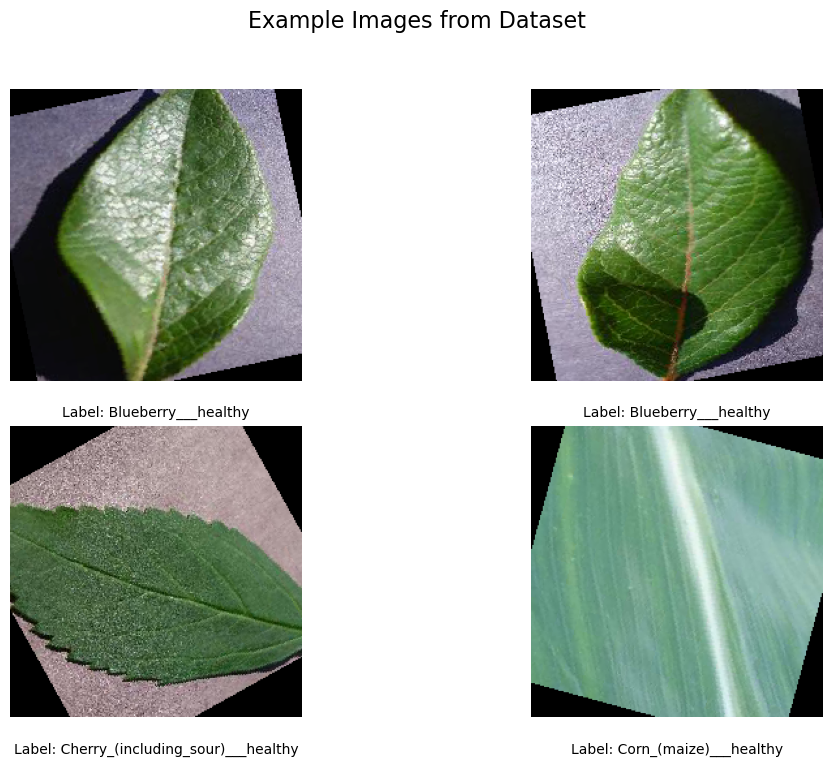

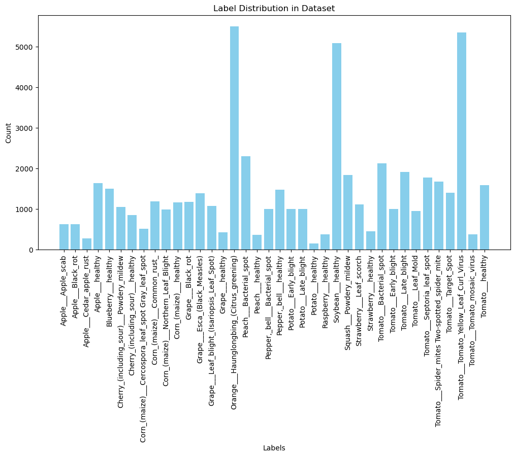

```python
def show_images(images, labels, num_rows=2, num_cols=2, title=None):
    """Display a grid of images with labels, showing label names instead of numbers."""
    fig, axes = plt.subplots(num_rows, num_cols, figsize=(12, 8))
    axes = axes.flatten()
    for i, (img, ax) in enumerate(zip(images, axes)):
        img = img.numpy().transpose((1, 2, 0))
        mean = np.array([0.485, 0.456, 0.406])  # Normalising mean
        std = np.array([0.229, 0.224, 0.225])   # Normalising standard deviation
        img = std * img + mean                  # Unnormalise the image
        img = np.clip(img, 0, 1)                # Making sure the image values are valid
        ax.imshow(img)
        ax.set_title(f'Label: {color_dataset.classes[labels[i]]}', fontsize=10, y=-0.15)  # Adjust label position
        ax.axis('off')
    plt.tight_layout()
    if title:
        plt.subplots_adjust(top=0.85)
        plt.suptitle(title, fontsize=16, y=0.95)
    plt.show()

def plot_label_distribution(labels, classes):
    """Plot a bar chart showing label distribution."""
    plt.figure(figsize=(12, 6))
    counts = np.bincount(labels)
    plt.bar(classes, counts, color='skyblue')
    plt.xlabel('Labels')
    plt.ylabel('Count')
    plt.title('Label Distribution in Dataset')
    plt.xticks(rotation=90)
    plt.show()

# Sample images to display
num_samples = 4  # Displaying four images
indices = np.random.choice(len(color_dataset), num_samples, replace=False)
samples = [color_dataset[i] for i in indices]
images, labels = zip(*samples)  # Separate images and labels

# Show images in a 2x2 grid
show_images(images, labels, title="Example Images from Dataset")

# Get and plot labels
all_labels = [sample[1] for sample in color_dataset]  # Get all labels from the dataset
plot_label_distribution(all_labels, color_dataset.classes)
```

### Observations from Visual and Statistical Data Analysis

As observed in the displayed images, there is noticeable variability in image quality across different samples. This variation includes differences in lighting, scale, and background, which can influence the model's ability to learn effectively. Moving forward, we will consider these quality variations in our data preprocessing and augmentation strategies to ensure that our model is robust to these inconsistencies.

Furthermore, the bar chart of label distribution reveals that classes such as `soybean_healthy`, `tomato_tomato__yellow_leaf_curl_virus`, and `orange_huanglongbing_(citrus_greening)` have significantly higher counts compared to others. This imbalance in the dataset prompts should be kept in mind moving forward going into the training process.

## 2.4 Splitting Data into Train/Validation/Test Sets

Proper data management is essential for effective machine learning. We need to divide the data into separate sets for training, validation, and testing. This segmentation facilitates the different phases of model training and ensures a systematic approach to model evaluation:

- **Training Set (70% of the dataset):** The majority of the data is used for training the model. This set helps the model learn the characteristics of various plant diseases and healthy plant conditions from the augmented images, aiming to improve its ability to make accurate predictions.
- **Validation Set (15% of the dataset):** The validation subset tunes the model's parameters and prevents overfitting. Regular validation during the training process allows for ongoing adjustments and improvements to the model's architecture and learning parameters based on performance metrics that the validation data provides.
- **Test Set (15% of the dataset):** After training, this set is used to evaluate the model's final performance. It provides an unbiased assessment of how well the model can generalise new, unseen data, which is needed to evaluate the model by seeing how it will practically work in real-world scenarios.

**Reference**:

- **Encord Blog** discusses the importance of proper data segmentation in machine learning projects. This resource helps understand why the splitting of data into training, validation, and test sets is critical for developing reliable machine learning models. Learn more from their insights on data segmentation and their recommended split ratio [here](https://encord.com/blog/train-val-test-split/#:~:text=The%20training%20set%20data%20must,10%2D20%25%20test%20data).

```python
# Calculate split sizes
dataset_size = len(color_dataset)
train_size = int(0.7 * dataset_size)
val_size = int(0.15 * dataset_size)
test_size = dataset_size - train_size - val_size

# Split dataset
train_dataset, val_dataset, test_dataset = random_split(
    color_dataset, [train_size, val_size, test_size],
    generator=torch.Generator().manual_seed(42)  # Ensures reproducibility
)

# Create DataLoaders
train_loader = torch.utils.data.DataLoader(train_dataset, batch_size=32, shuffle=True, num_workers=4)
val_loader = torch.utils.data.DataLoader(val_dataset, batch_size=32, shuffle=False, num_workers=4)
test_loader = torch.utils.data.DataLoader(test_dataset, batch_size=32, shuffle=False, num_workers=4)

print(f"""Dataset split:
Training samples: {len(train_dataset)} ({len(train_dataset)/dataset_size:.0%})
Validation samples: {len(val_dataset)} ({len(val_dataset)/dataset_size:.0%})
Test samples: {len(test_dataset)} ({len(test_dataset)/dataset_size:.0%})""")
```

```
Dataset split:
Training samples: 38013 (70%)
Validation samples: 8145 (15%)
Test samples: 8147 (15%)
```

**Insight:** As observed from the dataset distribution:

- The **training set** includes **70%** of the total data, ensuring that the model has enough data to learn from, which is needed for training robust machine learning models.
- The **validation and test sets** each take up **15%**. This equal split supports thorough model evaluation — validation for model tuning and testing to assess generalisation capability on unseen data.

This strategic division of data helps mitigate overfitting and underfitting, promoting a well-rounded learning and evaluation process.

## 3. Custom CNN Architecture for Plant Disease Detection

This chapter explores the construction and functionality of a custom Convolutional Neural Network (CNN) specifically designed for the task of detecting plant diseases from images.

### 3.1 Custom CNN: Layer-by-Layer Implementation

The custom CNN below, PlantDiseaseCNN, includes two main convolutional blocks followed by pooling, dropout for regularisation, and fully-connected layers to perform classification. The development of this model was informed by best practices and examples from the [PyTorch documentation](https://pytorch.org/docs/stable/nn.html), as well as practical insights from the YouTube tutorial ["Exploring Machine Learning with PyTorch"](https://www.youtube.com/watch?v=jztwpsIzEGc&ab_channel=NicholasRenotte) by Nicholas Renotte, which discusses machine learning techniques using PyTorch.

```python
class PlantDiseaseCNN(nn.Module):
    """
    Custom CNN for plant disease classification. This model includes convolutional layers,
    max pooling, dropout for regularisation, and fully-connected layers.
    """
    def __init__(self, num_classes, dropout_prob=0.5):
        super(PlantDiseaseCNN, self).__init__()

        # Feature extractor
        self.features = nn.Sequential(
            # First convolutional layer processes 3-channel images (RGB), using 32 filters of size 3x3.
            nn.Conv2d(3, 32, kernel_size=3, padding=1),  # Input: 3-channel 224x224
            nn.ReLU(),
            nn.MaxPool2d(kernel_size=2),  # Output: 32x112x112
            nn.Conv2d(32, 64, kernel_size=3, padding=1),  # Input: 32x112x112
            nn.ReLU(),
            nn.MaxPool2d(kernel_size=2),  # Output: 64x56x56
            nn.Dropout(dropout_prob)      # Regularization layer to prevent overfitting
        )
        # Classifier
        self.classifier = nn.Sequential(
            # Flatten the output of the feature extractor to pass to the fully connected layer.
            nn.Linear(64*56*56, 128),  # Flatten: 64*56*56
            nn.ReLU(),
            nn.Dropout(dropout_prob),
            nn.Linear(128, num_classes)
        )

    # Forward pass through the network
    def forward(self, x):
        x = self.features(x)
        x = x.view(x.size(0), -1)  # Flatten the output for the classifier
        return self.classifier(x)  # Pass the flattened output through the classifier

# Initialise the model
num_classes = len(color_dataset.classes)
model = PlantDiseaseCNN(num_classes=num_classes, dropout_prob=0.5)
print(f"Model has been initalised with {num_classes} output classes")
```

```
Model has been initalised with 38 output classes
```

### Detailed Explanation of the PlantDiseaseCNN Architecture

After setting up the `PlantDiseaseCNN` class, it is important to understand each component and its role in the model. This understanding will aid in grasping how the model processes input images and makes classifications:

#### Convolutional Layers

- **First Convolutional Block:**
  - **Layer Input**: Takes an input with 3 colour channels (RGB) and a resolution of 224x224 pixels.
  - **Convolution (`Conv2d`)**: Applies 32 filters of size 3x3 with padding set to 1. This layer helps in detecting basic features like edges and textures without reducing the spatial dimensions due to padding.
  - **Activation (`ReLU`)**: Applies the Rectified Linear Unit activation function which brings non-linearity to the model, allowing it to learn more complex patterns.
  - **Pooling (`MaxPool2d`)**: Applies a 2x2 max pooling operation which reduces the spatial dimensions of the output from the previous layer by half (from 224x224 to 112x112). This reduces the computational complexity and helps in making the detection of features invariant to scale and orientation.
- **Second Convolutional Block:**
  - **Layer Input**: Receives the output from the first block, now with 32 feature maps of size 112x112.
  - **Convolution (`Conv2d`)**: Increases the depth of the feature maps from 32 to 64 using filters of the same size (3x3) with padding, maintaining the dimension due to padding.
  - **Activation (`ReLU`)**: Continues to add non-linearity to the model, useful for learning deeper features required for the plant images.
  - **Pooling (`MaxPool2d`)**: Further reduces the dimensions from 112x112 to 56x56, focusing the model on the most prominent and salient features.

#### Fully Connected Layers (Classifier)

- **Flattening**: Before passing into fully connected layers, the output from the last pooling layer is flattened into a single long vector.
- **First Linear Layer (`Linear`)**: Transforms the flattened vector from the convolutional base into a vector of size 128. This layer begins the process of classification, interpreting the features extracted by the convolutions.
- **Activation (`ReLU`)**: Adds non-linearity after the first fully connected layer.
- **Second Linear Layer (`Linear`)**: Reduces the dimension from 128 to the number of classes (`num_classes`), which corresponds to the number of plant diseases the model is trained to identify.

## 3.2 Visualising the Model Architecture

Now we have successfully defined and initialised the `PlantDiseaseCNN` model! It is beneficial to visually summarise the the model to better understand its structure and the computational resources it requires. Below is a table summary generated using `torchinfo`, which provides an overview of the model's architecture.

```python
print("Custom CNN Summary:")
print(summary(model, input_size=(1, 3, 224, 224)))
```

```
Custom CNN Summary:
==========================================================================================
Layer (type:depth-idx)                   Output Shape              Param #
==========================================================================================
PlantDiseaseCNN                          [1, 38]                   --
├─Sequential: 1-1                        [1, 64, 56, 56]           --
│    └─Conv2d: 2-1                       [1, 32, 224, 224]         896
│    └─ReLU: 2-2                         [1, 32, 224, 224]         --
│    └─MaxPool2d: 2-3                    [1, 32, 112, 112]         --
│    └─Conv2d: 2-4                       [1, 64, 112, 112]         18,496
│    └─ReLU: 2-5                         [1, 64, 112, 112]         --
│    └─MaxPool2d: 2-6                    [1, 64, 56, 56]           --
│    └─Dropout: 2-7                      [1, 64, 56, 56]           --
├─Sequential: 1-2                        [1, 38]                   --
│    └─Linear: 2-8                       [1, 128]                  25,690,240
│    └─ReLU: 2-9                         [1, 128]                  --
│    └─Dropout: 2-10                     [1, 128]                  --
│    └─Linear: 2-11                      [1, 38]                   4,902
==========================================================================================
Total params: 25,714,534
Trainable params: 25,714,534
Non-trainable params: 0
Total mult-adds (M): 302.67
==========================================================================================
Input size (MB): 0.60
Forward/backward pass size (MB): 19.27
Params size (MB): 102.86
Estimated Total Size (MB): 122.73
==========================================================================================
```

### Insights from the Model Summary

- **Architecture Details**: The model consists of two main sections—a feature extractor with convolutional layers, ReLU activations, and pooling, and a classifier that includes fully connected layers. This structure helps in understanding how inputs are processed and classified.
- **Output Dimensions**: Each layer's output shape provides clarity on how input data dimensions are transformed as they pass through the model.
- **Parameter Count**: The detailed breakdown of parameters per layer helps gauge the learning capabilities and complexity of the model.
- **Computational Requirements**:
  - **Total Parameters**: Shows the overall complexity of the model based on the number of parameters.
  - **Total Mult-adds**: Shows the computational effort required for one forward pass.
  - **Memory Breakdown**:
    - **Input size**: Indicates the memory requirements for storing the input.
    - **Forward/backward pass size**: Memory needed during operations and during error back-propagation.
    - **Params size**: Shows the memory needed to store the model’s parameters.
    - **Estimated Total Size**: Gives an overall estimate of memory usage during the model operation.

# 4. Training Pipeline and Evaluation

This chapter will guide you through setting up the training and evaluation environment for our deep learning model, specifically focusing on the custom CNN model using PyTorch. We will go through configuring the device settings, initialising the model, training, validating, and finally testing the model's performance on unseen data.

## 4.1 Setup: Device and Optimiser Configuration

In this section, we prepare the computational environment and settings needed for training our neural network. We specify whether to use a CPU or GPU based on availability, which affects the speed of training. The optimiser is also defined here, which is crucial for updating network weights effectively during training.

```python
# Set device to GPU if available, otherwise CPU
device = torch.device("cuda" if torch.cuda.is_available() else "cpu")
model.to(device)  # Move model to the device

criterion = nn.CrossEntropyLoss()
optimizer = optim.Adam(model.parameters(), lr=0.001)
```

**Tip:** The lines `device = torch.device("cuda" if torch.cuda.is_available() else "cpu")` and `model.to(device)`assigns the model to a GPU if one is available, otherwise it utilises the CPU. Using a GPU can significantly accelerate the training due to it being able to perform parallel operations, which is crucial for handling the computationally intensive tasks involved in training deep neural networks. This optimisation ensures your model can run efficiently on the most appropriate hardware at your disposal.

## 4.2 Training and Validation Loops

Training and validating the neural network involves multiple cycles (epochs) where the model learns from the training data and then checks its understanding by predicting on a separate validation set. This process helps us fine-tune the model parameters without seeing the test data, ensuring that we gauge the model's performance under unbiased conditions. The principles discussed in this section were developed with knowledge learnt through a course, which can be viewed [here](https://www.youtube.com/watch?v=V_xro1bcAuA&t=11492s&ab_channel=freeCodeCamp.org) by freeCodeCamp.org.

```python
# Define the train_model function to manage both training and validation phases
def train_model(model, train_loader, val_loader, optimizer, num_epochs=10):
    # Lists to store loss per epoch for results/visualisations
    train_losses = []
    val_losses = []

    for epoch in range(num_epochs):
        model.train()               # Set the model to training mode
        running_loss = 0.0          # Accumulate losses from each batch

        # Training loop
        for inputs, labels in train_loader:
            inputs, labels = inputs.to(device), labels.to(device)
            optimizer.zero_grad()
            outputs = model(inputs)              # Generate predictions (forward pass)
            loss = criterion(outputs, labels)
            loss.backward()                      # Backpropagate the errors to compute gradients
            optimizer.step()
            running_loss += loss.item()

        # Calculate average training loss for the epoch
        avg_train_loss = running_loss / len(train_loader)
        train_losses.append(avg_train_loss)

        # Validation loop
        model.eval()
        val_loss = 0.0
        with torch.no_grad():
            for inputs, labels in val_loader:
                inputs, labels = inputs.to(device), labels.to(device)
                outputs = model(inputs)
                loss = criterion(outputs, labels)    # Compute validation loss
                val_loss += loss.item()

        # Calculate average validation loss for the epoch
        avg_val_loss = val_loss / len(val_loader)
        val_losses.append(avg_val_loss)

        print(f"Epoch [{epoch+1}/{num_epochs}], Train Loss: {avg_train_loss:.4f}, Val Loss: {avg_val_loss:.4f}")

    # Return lists with the losses per epoch for training and validation
    return train_losses, val_losses

# Call the train_model function to handle the training and validation loops
train_losses, val_losses = train_model(model, train_loader, val_loader, optimizer, num_epochs=10)
```

```
Epoch [1/10], Train Loss: 2.2538, Val Loss: 1.3998
Epoch [2/10], Train Loss: 1.6207, Val Loss: 1.0068
Epoch [3/10], Train Loss: 1.3675, Val Loss: 0.8571
Epoch [4/10], Train Loss: 1.2446, Val Loss: 0.8046
Epoch [5/10], Train Loss: 1.1507, Val Loss: 0.8430
Epoch [6/10], Train Loss: 1.0637, Val Loss: 0.6424
Epoch [7/10], Train Loss: 1.0049, Val Loss: 0.6296
Epoch [8/10], Train Loss: 0.9547, Val Loss: 0.5456
Epoch [9/10], Train Loss: 0.9113, Val Loss: 0.5013
Epoch [10/10], Train Loss: 0.8626, Val Loss: 0.4987
```

## 4.3 Evaluating the Model on Test Data

After completing the training and validation phases, we assess the model's performance using the test data. This step is necessary because it simulates how the model will perform in real-world scenarios, where it needs to identify plant diseases from new images it hasn't previously encountered.

**Understanding Test Accuracy in the Context of Plant Disease Detection:** Test accuracy measures the proportion of test images for which the model correctly identifies the disease. For example, if the test accuracy is 90%, it means that for 90% of the test images, the model accurately predicted the disease class out of the possible categories (e.g., healthy, infected with disease X, infected with disease Y, etc.).

A high test accuracy indicates that our model is effective at distinguishing between different types of plant diseases and identifying healthy plants. This is particularly important in agricultural settings where accurate and early detection of plant diseases can lead to timely treatment, preventing spread and reducing losses. On the other hand, if the accuracy is lower than expected, it might suggest issues such as overfitting on the training data, underfitting due to a model that's too simple, or insufficient training data for some of the disease classes.

```python
# Evaluate the model on the test set
model.eval()

# Initialise test loss and accuracy tracking variables
test_loss = 0.0
correct = 0
total = 0

# No gradient updates needed for evaluation, which saves memory and computations
with torch.no_grad():
    for inputs, labels in test_loader:
        inputs, labels = inputs.to(device), labels.to(device)

        # Forward pass to get outputs
        outputs = model(inputs)

        # Calculate the batch loss
        loss = criterion(outputs, labels)
        test_loss += loss.item()

        # Determine predictions and update correct count
        _, predicted = torch.max(outputs, 1)
        total += labels.size(0)
        correct += (predicted == labels).sum().item()

avg_test_loss = test_loss / len(test_loader)
test_accuracy = correct / total * 100

print(f"Test Loss: {avg_test_loss:.4f}")
print(f"Test Accuracy: {test_accuracy:.2f}%")
```

```
Test Loss: 0.5550
Test Accuracy: 84.40%
```

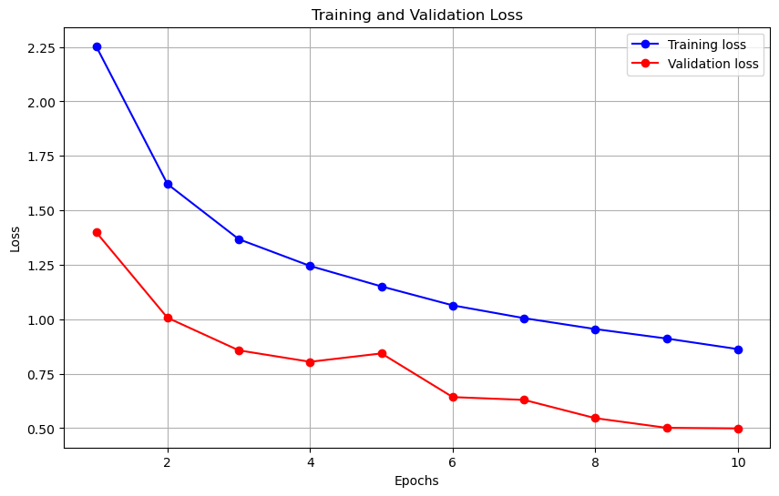

```
Test Loss: 0.5550
Test Accuracy: 84.40%
```

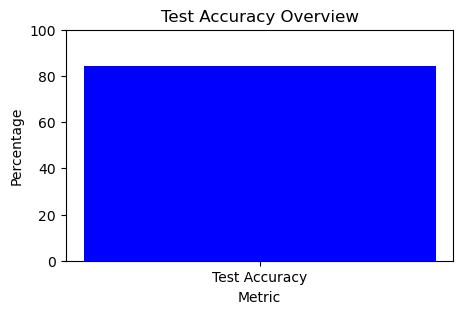

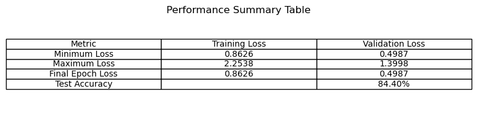

```python
# Plot training and validation loss
def plot_loss(train_losses, val_losses):
    epochs = range(1, len(train_losses) + 1)
    plt.figure(figsize=(10, 6))
    plt.plot(epochs, train_losses, 'bo-', label='Training loss')
    plt.plot(epochs, val_losses, 'ro-', label='Validation loss')
    plt.title('Training and Validation Loss')
    plt.xlabel('Epochs')
    plt.ylabel('Loss')
    plt.legend()
    plt.grid(True)
    plt.show()

# Call the function to plot the loss
plot_loss(train_losses, val_losses)

# Bar Chart for models accuracy
def summarise_test_results(test_loss, test_accuracy):
    print(f"Test Loss: {test_loss:.4f}")
    print(f"Test Accuracy: {test_accuracy:.2f}%")
    plt.figure(figsize=(5, 3))
    plt.bar('Test Accuracy', test_accuracy, color='blue')
    plt.xlabel('Metric')
    plt.ylabel('Percentage')
    plt.title('Test Accuracy Overview')
    plt.ylim([0, 100])
    plt.show()

    # Adding a vertical space after the plot
    display(HTML('<br>'))

# Call the function to display bar chart
summarise_test_results(avg_test_loss, test_accuracy)

def create_performance_table(train_losses, val_losses, test_accuracy):
    epochs = range(1, len(train_losses) + 1)
    min_train_loss = min(train_losses)
    min_val_loss = min(val_losses)
    max_train_loss = max(train_losses)
    max_val_loss = max(val_losses)
    final_train_loss = train_losses[-1]
    final_val_loss = val_losses[-1]

    fig, ax = plt.subplots(figsize=(10, 2))
    cell_text = [
        ["Minimum Loss", f"{min_train_loss:.4f}", f"{min_val_loss:.4f}"],
        ["Maximum Loss", f"{max_train_loss:.4f}", f"{max_val_loss:.4f}"],
        ["Final Epoch Loss", f"{final_train_loss:.4f}", f"{final_val_loss:.4f}"],
        ["Test Accuracy", "", f"{test_accuracy:.2f}%"]
    ]
    ax.table(cellText=cell_text, colLabels=["Metric", "Training Loss", "Validation Loss"], loc='center', cellLoc='center')
    ax.axis("off")

    plt.title("Performance Summary Table")
    plt.show()

# Call the function to display the performance table
create_performance_table(train_losses, val_losses, test_accuracy)
```

## 4.4 Visual Insight into Model Predictions

After quantitatively evaluating our model, it's equally important to qualitatively assess its performance. This section provides a visual insight into the model’s predictions, showcasing how the model performs with actual images from the test set. By observing the model's predictions alongside the true labels, we can gain actually see it in action to assess if it can accurately predict a sub-selection of plant images.

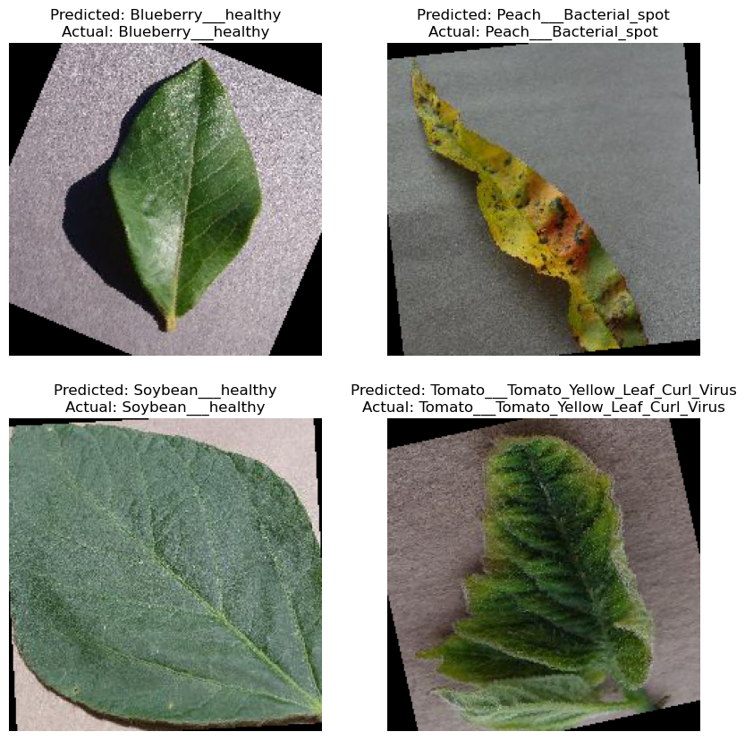

```python
# Function for visual insight into model predictions
def display_test_images(data_loader, model, device, classes, num_images=4):
    model.eval()
    images_so_far = 0
    fig = plt.figure(figsize=(10, 10))

    with torch.no_grad():         # Temporarily set all the required gradients to zero
        for i, (inputs, labels) in enumerate(data_loader):
            inputs = inputs.to(device)
            labels = labels.to(device)
            outputs = model(inputs) # Forward pass
            _, predictions = torch.max(outputs, 1)

            for j in range(inputs.size()[0]): # Iterate over all images in the batch
                images_so_far += 1
                ax = plt.subplot(num_images//2, 2, images_so_far)
                ax.axis('off')
                ax.set_title(f'Predicted: {classes[predictions[j]]}\nActual: {classes[labels[j]]}')
                img = inputs.cpu().data[j].numpy().transpose((1, 2, 0))
                mean = np.array([0.485, 0.456, 0.406])     # Normalising mean used during preprocessing
                std = np.array([0.229, 0.224, 0.225])      # Normalising std used during preprocessing
                img = std * img + mean                     # Unnormalise the image
                img = np.clip(img, 0, 1)                   # Clip values to make sure they are between 0 and 1
                plt.imshow(img)

                if images_so_far == num_images:
                    plt.show()
                    return

# Call the function to display test images
display_test_images(test_loader, model, device, color_dataset.classes, num_images=4)
```

### Analysis of Model Predictions:

The images displayed above allow us to visually assess the model's predictions. Correct predictions indicate that the model can effectively identify and categorise plant diseases. This shows that the goal of this model has been reached, and shows the capabilities it has. As you can see, when the model gets an example image, it is able to predict what disease/state it is in, which will be incredibly useful to farmers for improving yield and detecting problems as early on as possible.

# 5. Hyperparameter Analysis and Results Visualisation

In this chapter, our goal is to experiment with different hyperparameter configurations to find the optimal settings that enhance our model's performance. We aim to adjust and evaluate the following hyperparameters:

- **Learning Rate:** We compare the effects of learning rates of 0.01, 0.001, and 0.0001 to identify which setting provides better convergence without sacrificing the stability of the training process.
- **Dropout Rate:** We compare dropout rates of 0.1, 0.25, and 0.5 to determine their impact on the model's ability to generalise and prevent overfitting.
- **Batch Size:** We compare batch sizes of 16, 32, and 64 to see how they affect model training dynamics.

To effectively measure and visualize the impact of these hyperparameter adjustments, we use a combination of graphs and tables:

- **Graphical Visualisation:** We plot training and validation loss curves for each hyperparameter setting, allowing us to visually assess the effects of changes in real-time.
- **Table Summary:** We provide tables summarising key performance metrics such as minimum, maximum, and final epoch losses for training and validation phases. This improves our ability to quickly compare results across different settings.

## 5.1 Experiment 1: Learning Rate Analysis

Learning rates are pivotal in determining how significantly the model's weights are updated at the end of each training batch, directly influencing the convergence speed and stability. We explore three distinct learning rates:

- **0.0001:** A lower rate to investigate if it prevents overshooting while trading off with slower convergence.
- **0.001:** A more balanced approach.
- **0.01:** A higher rate tested to see if it can achieve faster convergence without destabilising the training process.

```python
# Function to plot the effects of hyperparameters on training and validation loss
def plot_hyperparameter_effects(hyperparams, results, title, param_name):
    plt.figure(figsize=(10, 6))
    for param, (train_losses, val_losses) in results.items():
        epochs = range(1, len(train_losses) + 1)
        plt.plot(epochs, train_losses, label=f'Train Loss - {param_name} {param}')
        plt.plot(epochs, val_losses, label=f'Val Loss - {param_name} {param}')

    plt.title(f'Effect of Different {param_name} on {title}')
    plt.xlabel('Epochs')
    plt.ylabel('Loss')
    plt.legend()
    plt.grid(True)
    plt.show()

# Function to create a results table for any hyperparameter
def create_hyperparameter_table(results, param_name):
    headers = f"{param_name} | Min Train Loss | Min Val Loss | Final Train Loss | Final Val Loss"
    print(headers)
    print("-" * len(headers))

    for param, (train_losses, val_losses) in results.items():
        min_train_loss = min(train_losses)
        min_val_loss = min(val_losses)
        final_train_loss = train_losses[-1]
        final_val_loss = val_losses[-1]
        print(f"{param:12} | {min_train_loss:14.4f} | {min_val_loss:12.4f} | {final_train_loss:16.4f} | {final_val_loss:14.4f}")
```

```
Training with learning rate: 0.01
Epoch [1/10], Train Loss: 3.8370, Val Loss: 3.3386
Epoch [2/10], Train Loss: 3.3506, Val Loss: 3.3382
Epoch [3/10], Train Loss: 3.3494, Val Loss: 3.3391
Epoch [4/10], Train Loss: 3.3492, Val Loss: 3.3376
Epoch [5/10], Train Loss: 3.3492, Val Loss: 3.3404
Epoch [6/10], Train Loss: 3.3493, Val Loss: 3.3381
Epoch [7/10], Train Loss: 3.3491, Val Loss: 3.3395
Epoch [8/10], Train Loss: 3.3492, Val Loss: 3.3379
Epoch [9/10], Train Loss: 3.3493, Val Loss: 3.3371
Epoch [10/10], Train Loss: 3.3492, Val Loss: 3.3391
Training with learning rate: 0.001
Epoch [1/10], Train Loss: 2.7833, Val Loss: 2.1546
Epoch [2/10], Train Loss: 2.2002, Val Loss: 1.5417
Epoch [3/10], Train Loss: 1.9110, Val Loss: 1.3493
Epoch [4/10], Train Loss: 1.7599, Val Loss: 1.2373
Epoch [5/10], Train Loss: 1.5933, Val Loss: 1.0212
Epoch [6/10], Train Loss: 1.4757, Val Loss: 0.9223
Epoch [7/10], Train Loss: 1.3748, Val Loss: 0.9036
Epoch [8/10], Train Loss: 1.3157, Val Loss: 0.8001
Epoch [9/10], Train Loss: 1.2446, Val Loss: 0.7391
Epoch [10/10], Train Loss: 1.2028, Val Loss: 0.7226
Training with learning rate: 0.0001
Epoch [1/10], Train Loss: 2.4356, Val Loss: 1.5192
Epoch [2/10], Train Loss: 1.7786, Val Loss: 1.1398
Epoch [3/10], Train Loss: 1.5422, Val Loss: 0.9522
Epoch [4/10], Train Loss: 1.3994, Val Loss: 0.8830
Epoch [5/10], Train Loss: 1.2994, Val Loss: 0.8037
Epoch [6/10], Train Loss: 1.2232, Val Loss: 0.7205
Epoch [7/10], Train Loss: 1.1678, Val Loss: 0.6852
Epoch [8/10], Train Loss: 1.1167, Val Loss: 0.6311
Epoch [9/10], Train Loss: 1.0758, Val Loss: 0.5991
Epoch [10/10], Train Loss: 1.0343, Val Loss: 0.5634
```

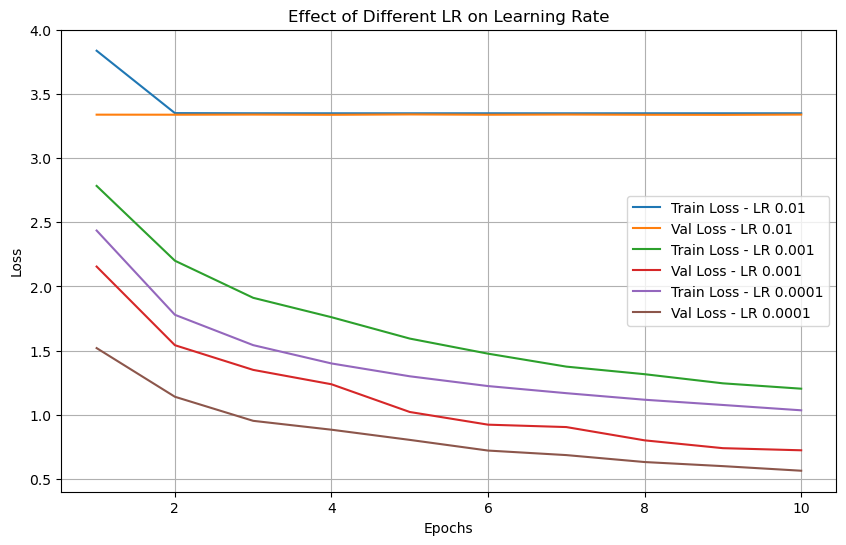

```
Learning Rate | Min Train Loss | Min Val Loss | Final Train Loss | Final Val Loss
---------------------------------------------------------------------------------
        0.01 |         3.3491 |       3.3371 |           3.3492 |         3.3391
       0.001 |         1.2028 |       0.7226 |           1.2028 |         0.7226
      0.0001 |         1.0343 |       0.5634 |           1.0343 |         0.5634
```

```python
# Experiment 1: Learning rate analysis
learning_rates = [0.01, 0.001, 0.0001]
results = {}

for lr in learning_rates:
    print(f"Training with learning rate: {lr}")

    # Reinitialise model and optimiser
    model = PlantDiseaseCNN(num_classes=num_classes, dropout_prob=0.5)
    model.to(device)
    optimizer = torch.optim.Adam(model.parameters(), lr=lr)

    train_losses, val_losses = train_model(model, train_loader, val_loader, optimizer, num_epochs=10)
    results[lr] = (train_losses, val_losses)

plot_hyperparameter_effects(learning_rates, results, 'Learning Rate', 'LR')
create_hyperparameter_table(results, 'Learning Rate')
```

## 5.2 Experiment 2: Dropout Rate Analysis

We examine the effects of three different dropout rates to find the optimal option to prevent overfitting:

- **0.1:** A lower dropout rate to test if the network can generalise without too much information loss.
- **0.25:** A middle rate that balances between regularisation and retaining feature learning capacity.
- **0.5:** A higher rate to determine how much dropout is too much before it starts to degrade the network's ability to learn effectively.

```
Training with dropout rate: 0.1
Epoch [1/10], Train Loss: 2.0189, Val Loss: 1.2397
Epoch [2/10], Train Loss: 1.2343, Val Loss: 0.9390
Epoch [3/10], Train Loss: 1.0407, Val Loss: 0.7667
Epoch [4/10], Train Loss: 0.8985, Val Loss: 0.6932
Epoch [5/10], Train Loss: 0.7911, Val Loss: 0.5895
Epoch [6/10], Train Loss: 0.7007, Val Loss: 0.5106
Epoch [7/10], Train Loss: 0.6461, Val Loss: 0.4736
Epoch [8/10], Train Loss: 0.5932, Val Loss: 0.4856
Epoch [9/10], Train Loss: 0.5557, Val Loss: 0.4037
Epoch [10/10], Train Loss: 0.5265, Val Loss: 0.3908
Training with dropout rate: 0.25
Epoch [1/10], Train Loss: 1.8843, Val Loss: 1.1281
Epoch [2/10], Train Loss: 1.1249, Val Loss: 0.8122
Epoch [3/10], Train Loss: 0.9297, Val Loss: 0.7064
Epoch [4/10], Train Loss: 0.8145, Val Loss: 0.6019
Epoch [5/10], Train Loss: 0.7202, Val Loss: 0.5808
Epoch [6/10], Train Loss: 0.6351, Val Loss: 0.4476
Epoch [7/10], Train Loss: 0.5774, Val Loss: 0.4155
Epoch [8/10], Train Loss: 0.5252, Val Loss: 0.3741
Epoch [9/10], Train Loss: 0.4832, Val Loss: 0.3867
Epoch [10/10], Train Loss: 0.4514, Val Loss: 0.2942
Training with dropout rate: 0.5
Epoch [1/10], Train Loss: 2.5445, Val Loss: 1.7488
Epoch [2/10], Train Loss: 1.8288, Val Loss: 1.3668
Epoch [3/10], Train Loss: 1.5259, Val Loss: 1.0559
Epoch [4/10], Train Loss: 1.3617, Val Loss: 0.8768
Epoch [5/10], Train Loss: 1.2656, Val Loss: 0.8219
Epoch [6/10], Train Loss: 1.2015, Val Loss: 0.7482
Epoch [7/10], Train Loss: 1.1096, Val Loss: 0.6649
Epoch [8/10], Train Loss: 1.0413, Val Loss: 0.5989
Epoch [9/10], Train Loss: 1.0051, Val Loss: 0.5656
Epoch [10/10], Train Loss: 0.9485, Val Loss: 0.5755
```

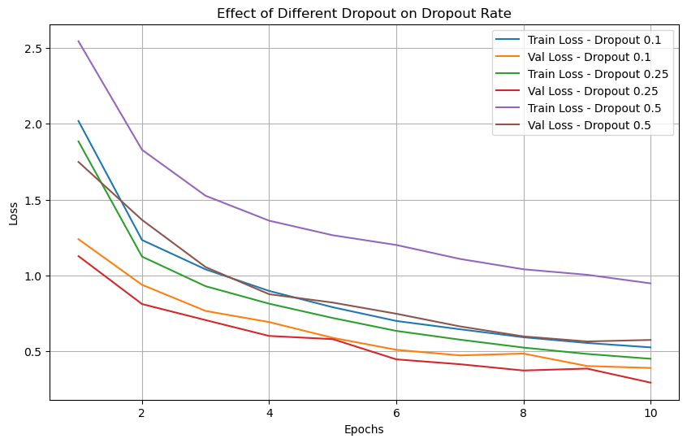

```
Dropout Rate | Min Train Loss | Min Val Loss | Final Train Loss | Final Val Loss
--------------------------------------------------------------------------------
         0.1 |         0.5265 |       0.3908 |           0.5265 |         0.3908
        0.25 |         0.4514 |       0.2942 |           0.4514 |         0.2942
         0.5 |         0.9485 |       0.5656 |           0.9485 |         0.5755
```

```python
# Experiment 2: Dropout rate analysis
dropout_rates = [0.1, 0.25, 0.5]
results_dropout = {}

for dr in dropout_rates:
    print(f"Training with dropout rate: {dr}")
    model = PlantDiseaseCNN(num_classes=num_classes, dropout_prob=dr)
    model.to(device)
    optimizer = torch.optim.Adam(model.parameters(), lr=0.001)

    train_losses, val_losses = train_model(model, train_loader, val_loader, optimizer, num_epochs=10)
    results_dropout[dr] = (train_losses, val_losses)

plot_hyperparameter_effects(dropout_rates, results_dropout, 'Dropout Rate', 'Dropout')
create_hyperparameter_table(results_dropout, 'Dropout Rate')
```

## 5.3 Experiment 3: Batch Size Analysis

Batch size affects the model's training dynamics by influencing the accuracy of the gradient estimation and memory usage. We test three batch sizes to observe their impact on training:

- **16:** A smaller batch size which may provide a more robust gradient estimate at the cost of increased noise.
- **32:** A medium batch size that is a good compromise between learning stability and computational efficiency.
- **64:** A larger batch size tested to see if it accelerates training convergence without sacrificing too much model accuracy.

```
Training with batch size: 16
Epoch [1/10], Train Loss: 2.0407, Val Loss: 1.1176
Epoch [2/10], Train Loss: 1.4452, Val Loss: 0.9216
Epoch [3/10], Train Loss: 1.2741, Val Loss: 0.8246
Epoch [4/10], Train Loss: 1.1714, Val Loss: 0.7189
Epoch [5/10], Train Loss: 1.0858, Val Loss: 0.7266
Epoch [6/10], Train Loss: 1.0204, Val Loss: 0.6041
Epoch [7/10], Train Loss: 0.9622, Val Loss: 0.5846
Epoch [8/10], Train Loss: 0.9264, Val Loss: 0.5575
Epoch [9/10], Train Loss: 0.9068, Val Loss: 0.4762
Epoch [10/10], Train Loss: 0.8671, Val Loss: 0.5430
Training with batch size: 32
Epoch [1/10], Train Loss: 2.1827, Val Loss: 1.2986
Epoch [2/10], Train Loss: 1.6257, Val Loss: 1.0363
Epoch [3/10], Train Loss: 1.4602, Val Loss: 0.9531
Epoch [4/10], Train Loss: 1.3447, Val Loss: 0.8687
Epoch [5/10], Train Loss: 1.2822, Val Loss: 0.7713
Epoch [6/10], Train Loss: 1.2166, Val Loss: 0.7480
Epoch [7/10], Train Loss: 1.1618, Val Loss: 0.6799
Epoch [8/10], Train Loss: 1.1273, Val Loss: 0.6429
Epoch [9/10], Train Loss: 1.0989, Val Loss: 0.6165
Epoch [10/10], Train Loss: 1.0407, Val Loss: 0.5651
Training with batch size: 64
Epoch [1/10], Train Loss: 2.1683, Val Loss: 1.2154
Epoch [2/10], Train Loss: 1.4342, Val Loss: 0.9571
Epoch [3/10], Train Loss: 1.2222, Val Loss: 0.7623
Epoch [4/10], Train Loss: 1.1001, Val Loss: 0.6933
Epoch [5/10], Train Loss: 1.0224, Val Loss: 0.6205
Epoch [6/10], Train Loss: 0.9373, Val Loss: 0.5275
Epoch [7/10], Train Loss: 0.8708, Val Loss: 0.4927
Epoch [8/10], Train Loss: 0.8112, Val Loss: 0.4235
Epoch [9/10], Train Loss: 0.7721, Val Loss: 0.4633
Epoch [10/10], Train Loss: 0.7426, Val Loss: 0.3876
```

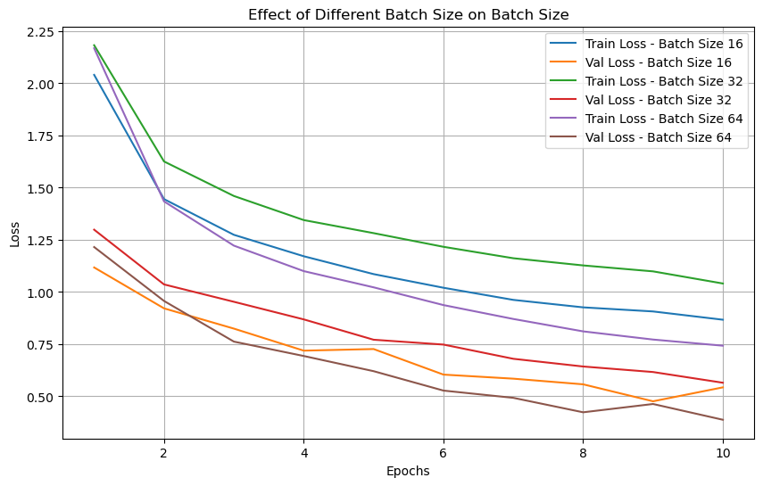

```
Batch Size | Min Train Loss | Min Val Loss | Final Train Loss | Final Val Loss
------------------------------------------------------------------------------
          16 |         0.8671 |       0.4762 |           0.8671 |         0.5430
          32 |         1.0407 |       0.5651 |           1.0407 |         0.5651
          64 |         0.7426 |       0.3876 |           0.7426 |         0.3876
```

```python
# Experiment 3: Batch size analysis
batch_sizes = [16, 32, 64]
results_batch = {}

for bs in batch_sizes:
    print(f"Training with batch size: {bs}")
    train_loader = torch.utils.data.DataLoader(train_dataset, batch_size=bs, shuffle=True)
    val_loader = torch.utils.data.DataLoader(val_dataset, batch_size=bs)

    model = PlantDiseaseCNN(num_classes=num_classes, dropout_prob=0.5)
    model.to(device)
    optimizer = torch.optim.Adam(model.parameters(), lr=0.001)

    train_losses, val_losses = train_model(model, train_loader, val_loader, optimizer, num_epochs=10)
    results_batch[bs] = (train_losses, val_losses)

plot_hyperparameter_effects(batch_sizes, results_batch, 'Batch Size', 'Batch Size')
create_hyperparameter_table(results_batch, 'Batch Size')
```

## 5.4 Summary of Optimal Hyperparameter Findings

### Analysis of Hyperparameter Tuning

Our testing involved adjusting three key hyperparameters: learning rate, dropout rate, and batch size. The graphs and accompanying data tables reveal how each parameter affects training and validation loss across epochs.

#### Learning Rate Analysis:

Based on the graphs, a learning rate of **0.0001** offers the best convergence behavior, demonstrating efficient learning dynamics without significant oscillations or plateauing, therefore, it is the optimal choice.

#### Dropout Rate Analysis:

The dropout rate of **0.25** is chosen as the optimal setting. It effectively prevents overfitting and also allows the network to learn sufficient complex patterns from the training data.

#### Batch Size Analysis:

A batch size of **64** ensures that each training epoch is not only computationally efficient but also effective in minimising loss, therefore, it is the optimal choice.

### Conclusion

The optimal settings for our Plant Disease CNN model are:

- **Learning Rate:** 0.0001
- **Batch Size:** 64
- **Dropout Rate:** 0.25

These parameters collectively enhance the model’s learning efficacy and robustness in handling the complex variability within plant disease classification. By employing these settings, we lay a strong foundation for the model, optimising it for both accuracy and generalisation - useful for real-world application.

# 6. Comparison of Similar Tutorials

In this tutorial, we reference multiple online resources, but in this chapter we focus on comparing our approach to two similar tutorials: the [Cassava Leaf Disease Detection tutorial](https://github.com/aswintechguy/Deep-Learning-Projects/blob/main/Cassava%20Leaf%20Disease%20Detection%20-%20Pytorch%20Image%20Classification/Cassava%20Leaf%20Disease%20Detection%20-%20Pytorch%20Tutorial.ipynb), which uses PyTorch for image classification, and the [Plant Disease Detection Using Mask R-CNN tutorial](https://github.com/AarohiSingla/Plant-Disease-Detection-Using-Mask-R-CNN/blob/main/test_model.ipynb), which uses a Mask R-CNN model for disease detection.

### Cassava Leaf Disease Detection Tutorial

- **Objective:** Detect diseases in cassava crops to help prevent spread by enabling quick decisions due to quick detection.
- **Model:** Uses a pretrained ResNet-152 network, achieving 87% accuracy.
- **Focus:** Designed specifically to the Cassava Leaf Disease dataset available on Kaggle.
- **Pros:**
  - High accuracy at 87% with an advanced transfer learning model.
  - Good exploratory data analysis and visualisation.
- **Cons:**
  - Limited to one dataset, reducing generalisation.
  - Demands higher computational resources than our Custom CNN Tutorial.

### Plant Disease Detection Using Mask R-CNN Tutorial

- **Objective:** Detect and localise disease symptoms on plant leaves.
- **Model:** Uses a pretrained Mask R-CNN (with a ResNet backbone) to provide both classification and segmentation.
- **Focus:** Can be applied to a variety of plant types and diseases with spatial localisation.
- **Pros:**
  - Offers precise localisation through segmentation masks.
  - Useful for detailed diagnostic research.
- **Cons:**
  - More complex setup and therefore slower inference than our Custom CNN Tutorial.
  - Requires greater computational power. Due to this, it's not as beginner friendly as the other two approaches.

### Our Custom CNN Tutorial

- **Objective:**  
  Develop a flexible, custom-designed CNN that can detect various plant diseases across multiple datasets with a focus on real-time applicability in field conditions.
- **Model Architecture:**
  - A simple but effective CNN architecture built using PyTorch.
  - Uses two convolutional blocks, dropout for regularisation, and fully connected layers to ensure adaptability and ease of tuning.
- **Dataset and Scope:**
  - Uses the PlantVillage dataset, which includes 38 classes of both healthy and diseased leaves, but the model is not limited to this one dataset.
  - The diverse dataset ensures the model learns varied visual features, making it adaptable to other plant disease datasets with minor modifications.
- **Performance and Metrics:**
  - Achieves competitive performance (e.g., ~84% test accuracy) while maintaining lower computational overhead compared to the other more complex models.
  - Benefits from hyperparameter analysis, with optimal settings such as a Learning Rate of 0.0001, Batch Size of 64, and Dropout of 0.25 to balance training efficiency and generalisation.
- **Computational Needs and Accessibility:**
  - Designed to be lightweight and adaptable.
  - Lower hardware requirements make it more accessible for users in resource-constrained environments or those new to deep learning.
- **Pros:**
  - **Flexibility:** Easily modifiable architecture suited for various plant disease datasets.
  - **Accessibility:** Lower computational demands allow broader adoption, including in-field deployments.
  - **Transparency:** Clear hyperparameter tuning and performance evaluation make the model understandable and reproducible.
- **Cons:**
  - **Initial Accuracy Variability:** Without careful fine-tuning, initial model performance can perform worse than the other two tutorial approaches.
  - **Additional Setup:** Requires users to experiment with hyperparameters and possibly integrate further optimisations for specific datasets.

### Key Differences

- **Architecture:**
  - The Cassava tutorial uses a deep ResNet-152 for classification,
  - The Mask R-CNN tutorial adds segmentation for localisation, and
  - Our tutorial uses a simpler, customisable CNN.
- **Dataset Flexibility:**
  - The Cassava tutorial is dataset-specific, while both our approach and the Mask R-CNN tutorial are designed to work across various plant disease datasets. This shows ours has real-world-applications as a focus due to its wide accessibility goals.
- **Computational Needs:**
  - The ResNet-152 and Mask R-CNN approaches are more resource-intensive compared to the moderate requirements of our custom CNN. This shows our pipeline is more focused for beginners.

# 7. Conclusion

🎉 **Congratulations!** You've successfully navigated through this tutorial on using PyTorch to detect plant diseases with a custom Convolutional Neural Network. This journey has hopefully provided you with the knowledge and understanding of the components needed to design, train, and evaluate a deep learning model, with real-world applications in agriculture in mind.

Throughout this tutorial, we've explored:

- **Data Management:** Efficient handling and preparation of our dataset.
- **Building a Custom CNN:** Implementation and insights.
- **Performance Evaluation:** Understanding the model’s effectiveness on unseen data.
- **Training Strategies:** Optimising our model through various hyper-parameters.

🚀 **What's next?** Dive deeper by adjusting hyper-parameters, experimenting with more complex models, or expanding your dataset. You can do this by combining the various optimal hyper-parameters into a single model and evaluate its performance.

🙏 **Thank you** for joining me in this tutorial.

**Happy coding!**

# 8. References

## Sources

#### Kaggle · PlantVillage Dataset

PlantVillage dataset used in this tutorial for plant disease detection.

[View Dataset](https://www.kaggle.com/datasets/abdallahalidev/plantvillage-dataset)

### GitHub · Cassava Leaf Disease Detection

Pytorch Tutorial for Cassava Leaf Disease Detection, a guide on using PyTorch for image classification which is used in chapter 6 as a comparison.

[View on GitHub](https://github.com/aswintechguy/Deep-Learning-Projects/blob/main/Cassava%20Leaf%20Disease%20Detection%20-%20Pytorch%20Image%20Classification/Cassava%20Leaf%20Disease%20Detection%20-%20Pytorch%20Tutorial.ipynb)

### GitHub · Plant Disease Detection Using Mask R-CNN

The 'test_model.ipynb' notebook in the GitHub repository is also used in chapter 6 as a comparison.

[View on GitHub](https://github.com/AarohiSingla/Plant-Disease-Detection-Using-Mask-R-CNN/blob/main/test_model.ipynb)

[figure not shown]

### YouTube · CodeWithAarohi

"Understanding PyTorch with a Comprehensive Tutorial" provides insights into PyTorch's functionalities and best practices for beginners.

[Watch Video](https://www.youtube.com/watch?v=cJpwQJp9flU)

[figure not shown]

### YouTube · Nicholas Renotte

"Exploring Machine Learning with PyTorch" provides insights into practical machine learning techniques using PyTorch.

[Watch Video](https://www.youtube.com/watch?v=jztwpsIzEGc)

[figure not shown]

### YouTube · KieCodes

This tutorial provides a detailed guide on using PyTorch for image data handling and machine learning model training.

[Watch Video](https://www.youtube.com/watch?v=igQeI29FIQM)

[figure not shown]

### YouTube · freeCodeCamp.org

This course provides insights into training and validating neural networks, emphasising practical implementations and optimisation strategies.

[Watch Video](https://www.youtube.com/watch?v=V_xro1bcAuA&t=11492s&ab_channel=freeCodeCamp.org)

[figure not shown]

### YouTube · NeuralNine

"Introduction to PyTorch for Beginners" explores fundamental concepts and basic implementations in PyTorch.

[Watch Video](https://www.youtube.com/watch?v=CtzfbUwrYGI)

### PyTorch Docs · Torchvision datasets

Official documentation for using torchvision's datasets with ImageFolder.

[View Documentation](https://pytorch.org/vision/stable/datasets.html#imagefolder)

### PyTorch Docs · Transforms

Guide to using transformations in PyTorch.

[View Documentation](https://pytorch.org/vision/stable/transforms.html)

### PyTorch Docs · nn Module

Guide to PyTorch's neural network (nn) module, providing functionalities and API usage for building deep learning models.

[View Documentation](https://pytorch.org/docs/stable/nn.html)

### Medium · Ahmet Ekiz

This website was used to help understand Jupyter Notebook markdown, including the tips/warning messages included in this tutorial.

[View Website](https://medium.com/@ahmetekiz/creating-table-of-contents-in-jupyter-notebook-52a7c696817f)

[figure not shown]

### YouTube · Deepsim

This video explains how to create a table of contents in Jupyter Notebook which was used to help create the one in this tutorial"

[Watch Video](https://www.youtube.com/watch?v=YREIn1uTYO0)

### Encord Blog · Train-Val-Test Split

Understanding the Importance of Data Segmentation in Machine Learning

This blog post explains the significance of splitting datasets into training, validation, and test sets, outlining the typical percentages used and the rationale behind them which was used in chapter 2.4.

[Read Article](https://encord.com/blog/train-val-test-split/#:~:text=The%20training%20set%20data%20must,10%2D20%25%20test%20data.)